# Frameworks for Inference

Last updated: 2017-02-04

## Notes

## Readings

## Remember the Goal of Statistics

> "a way of taming **uncertainty**, of turning raw **data** into arguments that can resolve profound questions" (Amabile 1989)
- Success depends on evaluating the relative support for different models

## Models?

## Example: Wing Dimorphic Crickets

> Do long-winged crickets have a higher resting metabolic rate than short-winged crickets?

Controlling for body mass,

- Metabolic rates do not differ
- Average metabolic rate of long-wings is higher
- Average metabolic rate of long-wings is lower

## Example: Genetics of Corn Oil Content

> Which set of loci best predicts oil content in corn kernels?

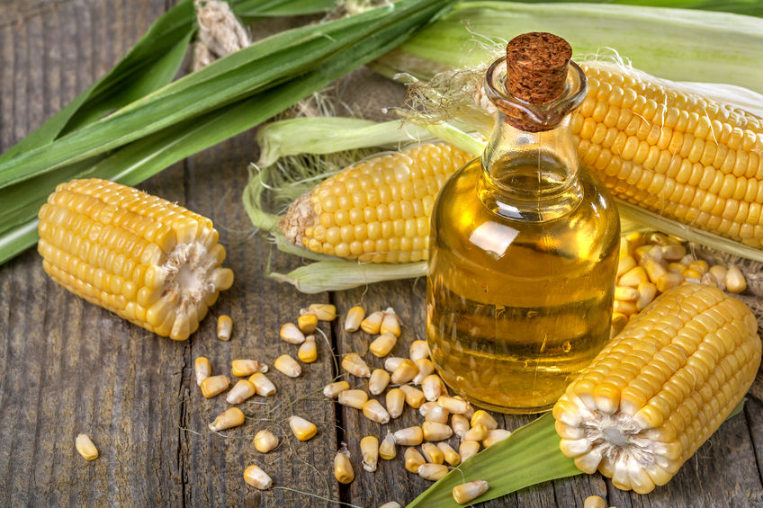

- Heritability of corn oil content is 0
- Different possible combinations of SNPs
- All additive
- Dominance
- Epistasis
- Structural variants

## Example: Canid relationships

> What are the phylogenetic relationships between dog breeds & other canids?

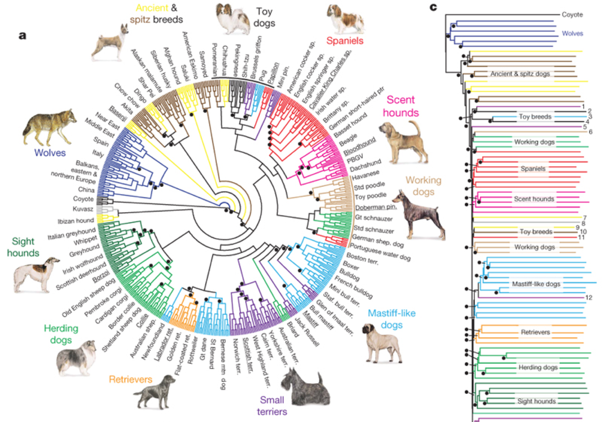

- Star phylogeny
- Single origin of dogs
- Ancient breeds are monophyletic
- Every possible tree….

## Example: Wing Dimorphic Crickets

> Do long-winged crickets have a higher resting metabolic rate than short-winged crickets?

Controlling for body mass,

- Metabolic rates do not differ
- Average metabolic rate of long-wings is higher
- Average metabolic rate of long-wings is lower

## Example: Wing Dimorphic Crickets

> Do long-winged crickets have a higher resting metabolic rate than short-winged crickets?

Controlling for body mass,

- Metabolic rates do not differ
- Average metabolic rate of long-wings is higher
- Average metabolic rate of long-wings is lower

## References

Amabile, T. 1989. Against All Odds Inside Statistics. Annenberg/CPB Collection; Intellimation [distributor].